# R Notebook

# Introduction to ggplot2 Homework

## Question 1

### Load in the libraries you need, and look at the backpack data. Take note of variable names and dimensions.

```r
glimpse(backpack)
```

```
Rows: 100
Columns: 9
$ backpack_weight <int> 9, 8, 10, 6, 8, 5, 8, 4, 5, 2, 8, 21, 11, 11, 12, 11, 13, 6, 10, 5, 20, 14, 11, 15, 1…
$ body_weight     <int> 125, 195, 120, 155, 180, 240, 170, 185, 130, 120, 135, 160, 170, 170, 125, 175, 145, …
$ ratio           <dbl> 0.0720000, 0.0410256, 0.0833333, 0.0387097, 0.0444444, 0.0208333, 0.0470588, 0.021621…
$ back_problems   <int> 1, 0, 1, 0, 0, 0, 0, 1, 0, 0, 0, 0, 0, 1, 1, 0, 1, 0, 1, 0, 0, 1, 0, 0, 0, 1, 0, 0, 0…
$ major           <fct> Bio, Philosophy, GRC, CSC, EE, History, CM, ARCE, Bio, Bio, Bus, ME, CPE, CPE, CS, CP…
$ year            <int> 3, 5, 4, 6, 2, 0, 3, 5, 4, 5, 3, 5, 4, 4, 3, 4, 4, 3, 3, 3, 2, 2, 5, 5, 3, 1, 4, 2, 2…
$ sex             <fct> Female, Male, Female, Male, Female, Male, Male, Female, Female, Female, Female, Male,…
$ status          <fct> U, U, U, G, U, G, U, U, U, U, U, U, U, U, U, U, U, U, U, U, U, U, U, U, U, U, U, U, U…
$ units           <int> 13, 12, 14, 0, 14, 0, 15, 18, 14, 8, 15, 12, 16, 16, 12, 16, 16, 16, 17, 14, 16, 12, …
```

## Question 2

### What is the distribution of backpack weights that students are carrying? Choose an appropriate graph to show the distribution.

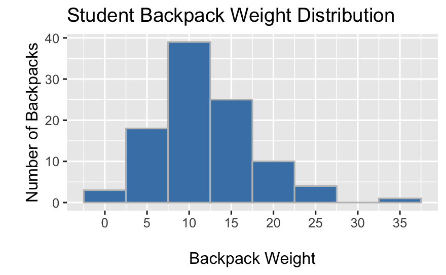

> histogram of the distribution of the weights carried by students more than half of the students carry a bag between 5 and 15 kgs(?) right skewed

## Question 3

### Are there differences in backpack weight between sex?

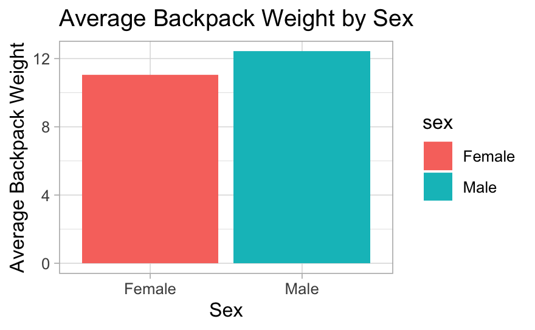

> shows the average backpack weight carried by male and female students males on average carry heavier backpacks, but not by much

Answer given

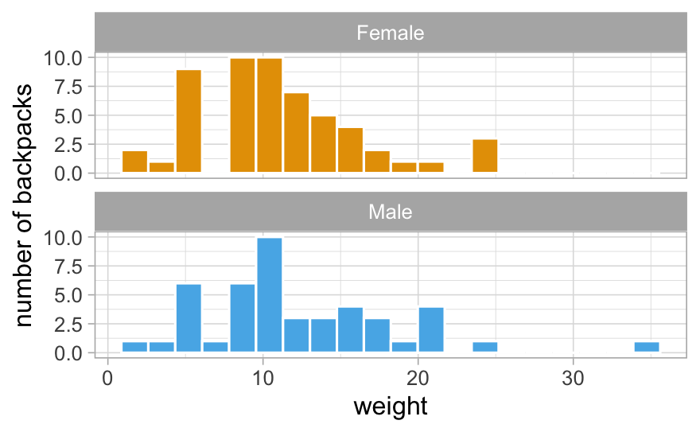

## Question 4

### What is the relationship between body weight and backpack weight?

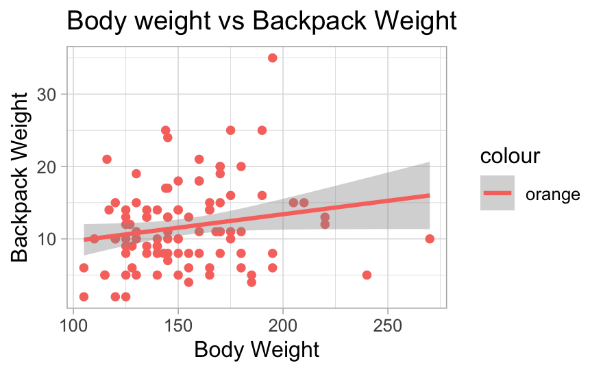

```r
ggplot(backpack) +
  aes(x = body_weight, y = backpack_weight, colour = "orange") +
  geom_point(show.legend = FALSE) +
  geom_smooth(method = lm) +
  labs(title = "Body weight vs Backpack Weight",
       x = "Body Weight",
       y = "Backpack Weight") +
  theme_light()
```

> Shows the relationship between body weight and backpack weight, seems like there is only a minimal (if any) relationship between the two variables

## Question 5

### Is this relationship different between men and women? Choose an appropriate plot and interpret your findings.

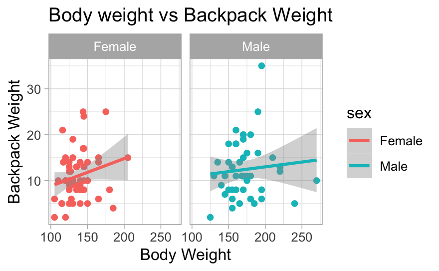

```r
ggplot(backpack) +
  aes(x = body_weight, y = backpack_weight, colour = sex) +
  geom_point(show.legend = FALSE) +
  geom_smooth(method = lm) +
  labs(title = "Body weight vs Backpack Weight",
       x = "Body Weight",
       y = "Backpack Weight") +
  facet_wrap(~ sex) +
  theme_light()
```

> perhaps more of a relationship in females

# These questions I didn’t answer on the night

## Question 6

### What proportion of students report back pain?

Answer given

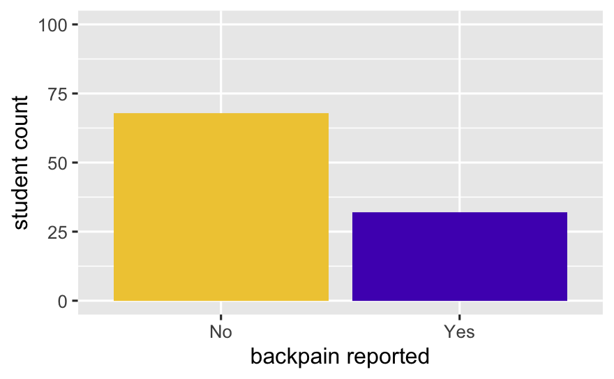

## Question 7

### Is this proportion different between men and women?

Answer given

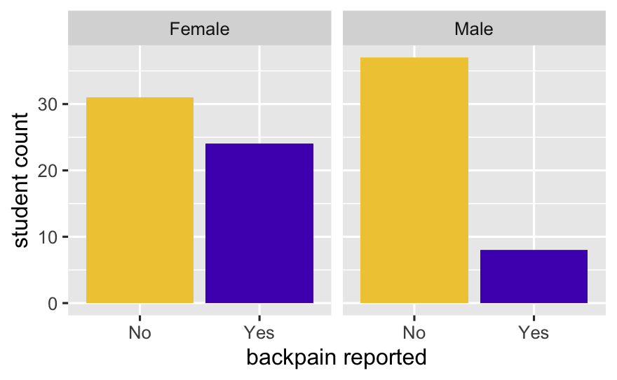

## Question 8

### Now you’ve investigated your data separately, create plots to describe the relationship between backpack weight, body weight, gender and reported backpain.

Try both backpack_weight and body_weight as well as the ratio.

Answer Given

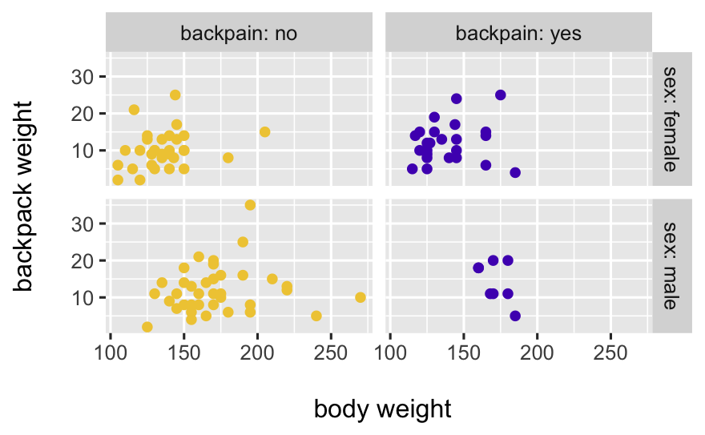

```r
pain_labels <- c("backpain: no", "backpain: yes")
names(pain_labels) <- c("No", "Yes")

sex_labels <- c("sex: female", "sex: male")
names(sex_labels) <- c("Female", "Male")


ggplot(backpack) +
  aes(x = body_weight, y = backpack_weight, color = backpain_labelled) +
  geom_point() +
  facet_grid(sex ~ backpain_labelled,
             labeller = labeller(backpain_labelled = pain_labels, sex = sex_labels)) +
  labs(x = "\n body weight", y = "backpack weight \n") +
      scale_color_manual(values=c('#f0ca41', '#5022bd'))+
theme(legend.position = "none")
```

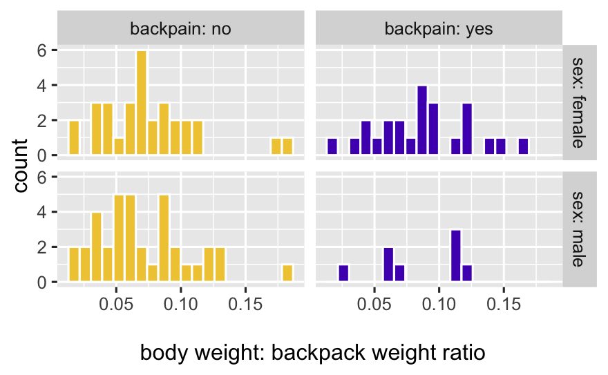

```r
ggplot(backpack) +
  geom_histogram(aes(x = ratio, fill = backpain_labelled), bins = 20, col = "white") +
  facet_grid(sex ~ backpain_labelled,
             labeller = labeller(backpain_labelled = pain_labels, sex = sex_labels)) +
  labs(x = "\n body weight: backpack weight ratio") +
      scale_fill_manual(values=c('#f0ca41', '#5022bd'))+
theme(legend.position = "none")
```